# Project 2

Arsalan

2022-07-28

## Introduction

In this case study we want to look at employee attributes to predict attrition rates. We also want to look at Income prediction using a regression model.

## Data Exploration

First we want to look at the data set from a broad perspective and look at any trends we might see

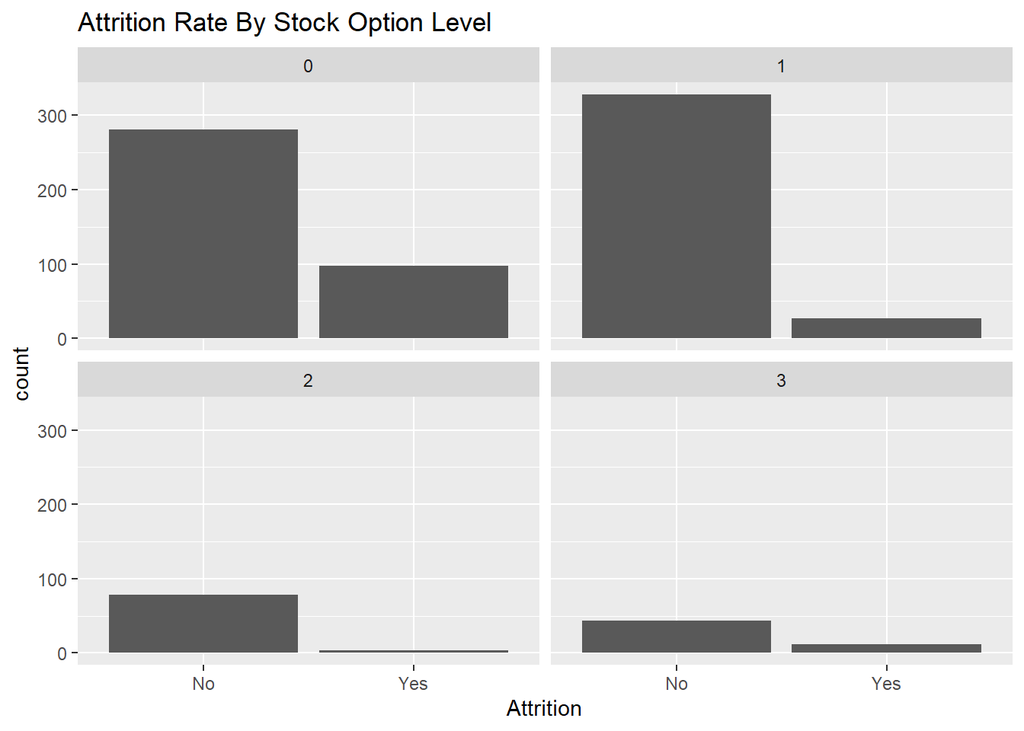

```r
plot = ggplot(data = data, aes(x = Attrition)) +
  geom_bar() + facet_wrap(~StockOptionLevel) + ggtitle("Attrition Rate By Stock Option Level")
plot
```

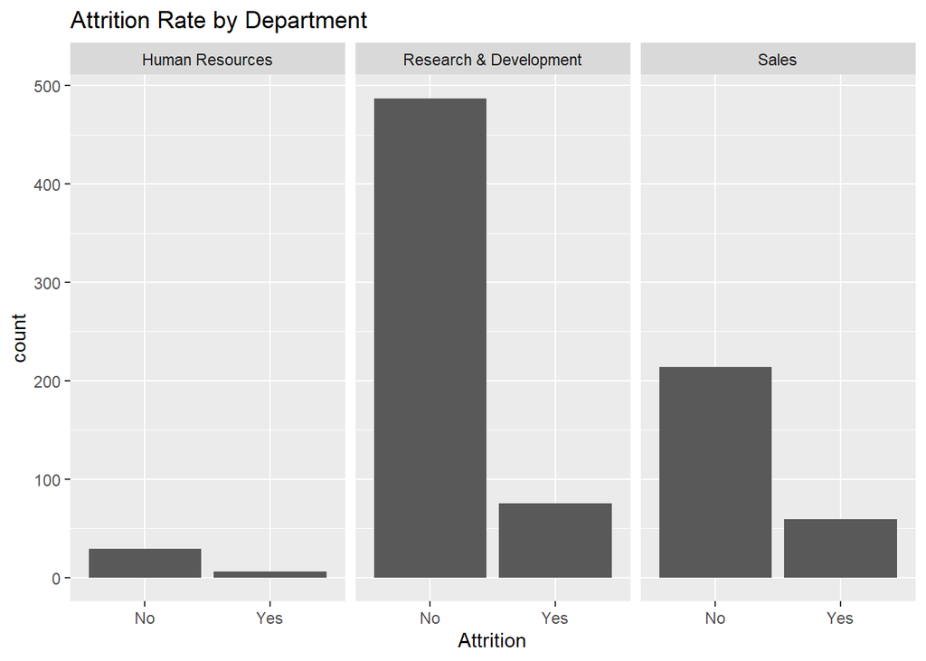

```r
plot = ggplot(data = data, aes(x = Attrition)) +
  geom_bar() + facet_wrap(~Department) + ggtitle("Attrition Rate by Department")
plot
```

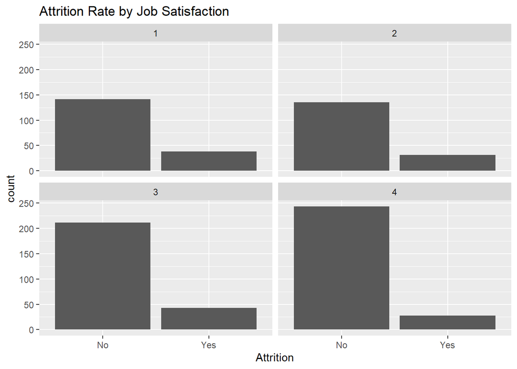

```r
plot = ggplot(data = data, aes(x = Attrition)) +
  geom_bar() + facet_wrap(~JobSatisfaction) + ggtitle("Attrition Rate by Job Satisfaction")
plot
```

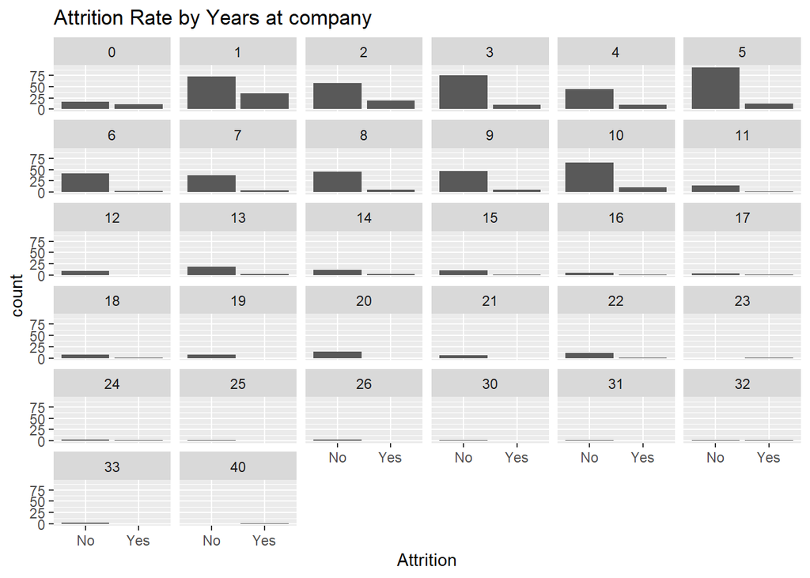

```r
plot = ggplot(data = data, aes(x = Attrition)) +
  geom_bar() + facet_wrap(~YearsAtCompany) + ggtitle("Attrition Rate by Years at company")
plot
```

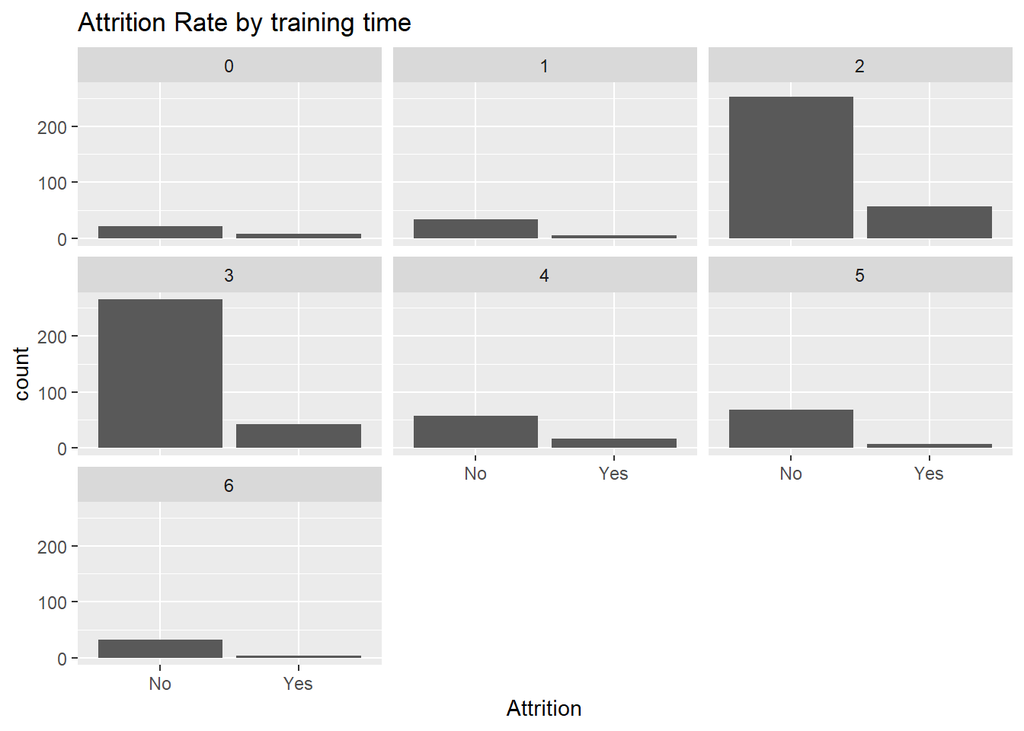

```r
plot = ggplot(data = data, aes(x = Attrition)) +
  geom_bar() + facet_wrap(~TrainingTimesLastYear) + ggtitle("Attrition Rate by training time")
plot
```

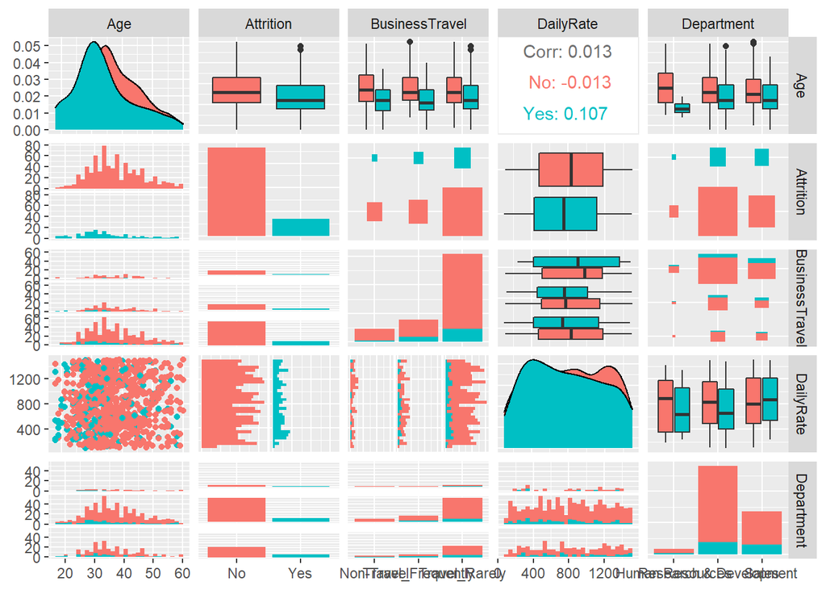

```r
ggpairs(data, columns = c(2, 3, 4,5, 6), aes(color = data$Attrition))
```

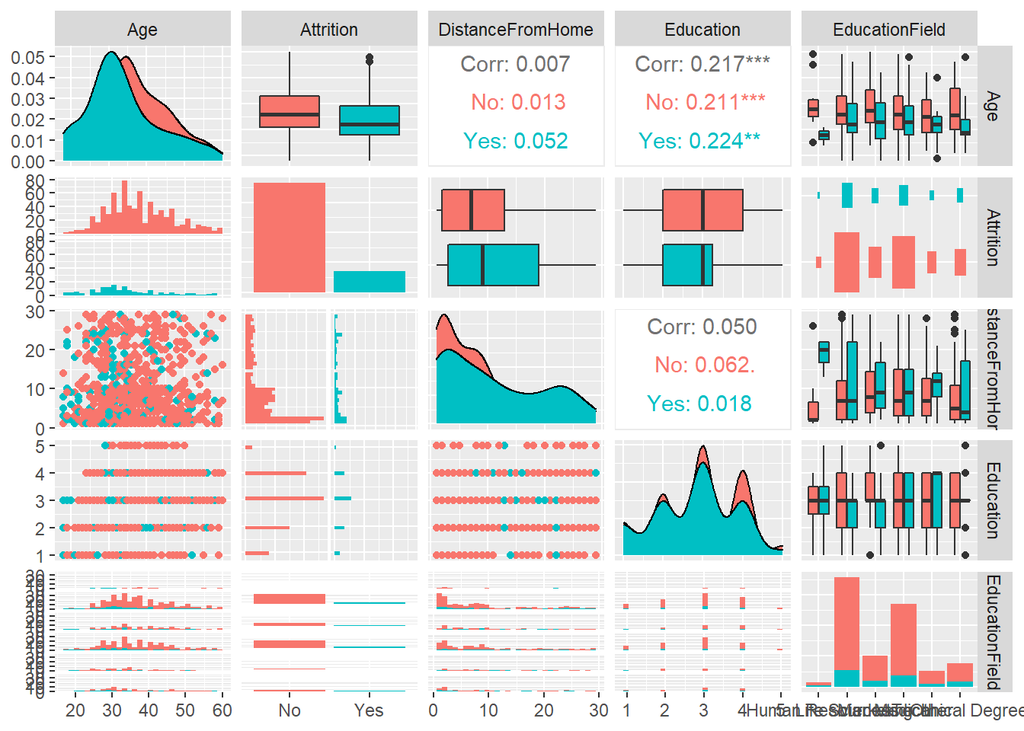

```r
ggpairs(data, columns = c(2, 3, 7,8,9),  aes(color = data$Attrition))
```

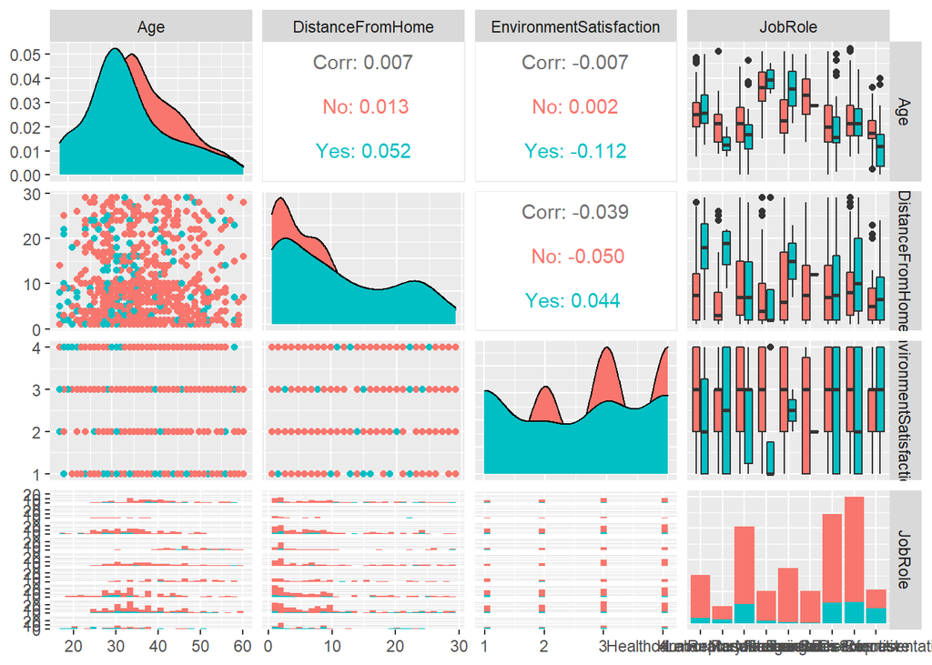

```r
ggpairs(data,columns = c(2,7,12,17), aes(color = data$Attrition))
```

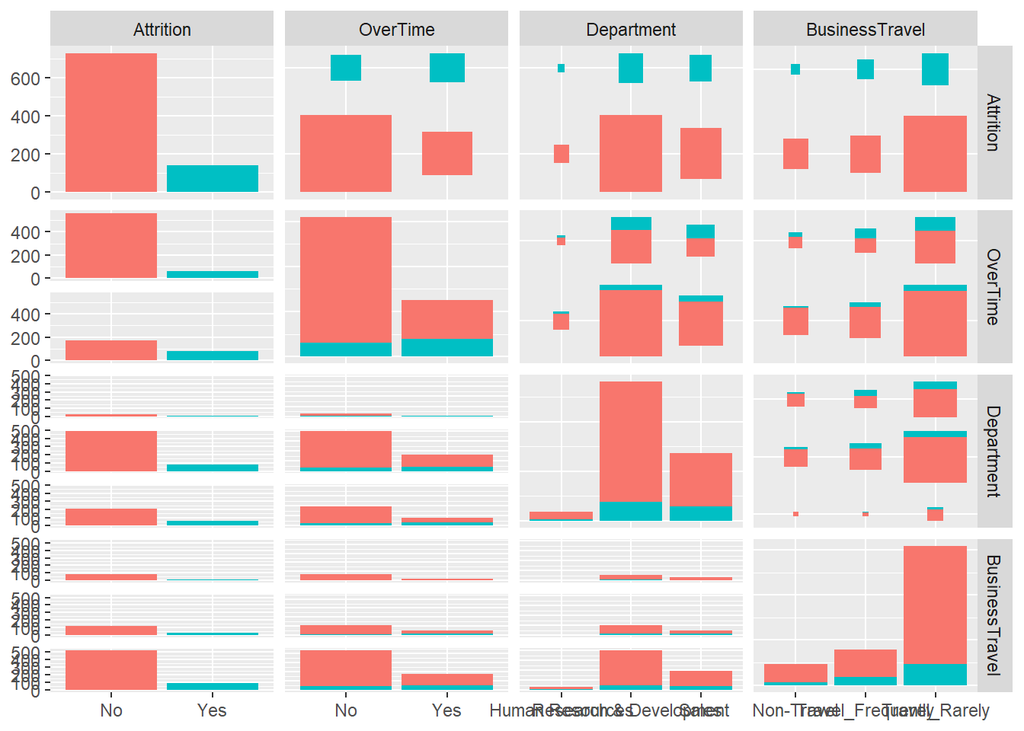

```r
ggpairs(data, columns = c(3, 24,6,4),  aes(color = data$Attrition))
```

```r
#environment Satisfaction, Hourly Rate Job Level and Job Role
```

## Naive Bayes for Attrition

# Initial Naive Bayes

Because we want to look at categorical variables to predict attrition. I felt that taking the Naive Bayes approach would be better. Our first model using (environment Satisfaction, Hourly Rate Job Level and Job Role) gets a fairly high accuracy and sensitivity but gives us a very low specificity. This is not good for predicting attrition rate. From here we adjust our model

```r
trainInd = sample(seq(1,dim(data)[1],1),round(.7*dim(data)[1]))
dataTrain = data[trainInd,]
dataTest = data[-trainInd,]

model = naiveBayes(x = dataTrain[c(4,6,12, 14,16,17,24)], dataTrain$Attrition)
CM = confusionMatrix(table(predict(model, dataTest[,c(4,6,12, 14,16,17,24)]), dataTest$Attrition))

CM
```

```
## Confusion Matrix and Statistics
##
##
##        No Yes
##   No  204  35
##   Yes  12  10
##
##                Accuracy : 0.8199
##                  95% CI : (0.7678, 0.8646)
##     No Information Rate : 0.8276
##     P-Value [Acc > NIR] : 0.664371
##
##                   Kappa : 0.2089
##
##  Mcnemar's Test P-Value : 0.001332
##
##             Sensitivity : 0.9444
##             Specificity : 0.2222
##          Pos Pred Value : 0.8536
##          Neg Pred Value : 0.4545
##              Prevalence : 0.8276
##          Detection Rate : 0.7816
##    Detection Prevalence : 0.9157
##       Balanced Accuracy : 0.5833
##
##        'Positive' Class : No
##
```

# Trying Naive Bayes with more columns, removing unrelated columns such as employee number

```r
masterAcc = matrix(nrow = 100)
masterSen = matrix(nrow = 100)
masterSpec = matrix(nrow = 100)
for(j in 1:100)
{
  set.seed(NULL)
  trainInd = sample(seq(1,dim(data)[1],1),round(.7*dim(data)[1]))
  dataTrain = data[trainInd,]
  dataTest = data[-trainInd,]


  model = naiveBayes(x = dataTrain[c(2,4:9,12:17, 19:24, 26, 28:36)], dataTrain$Attrition)
  CM = confusionMatrix(table(predict(model, dataTest[,c(2,4:9,12:17, 19:24, 26, 28:36)]), dataTest$Attrition))

  masterAcc[j] = CM$overall['Accuracy']
  masterSen[j] = CM$byClass['Sensitivity']
  masterSpec[j] = CM$byClass['Specificity']

}

MeanAcc = colMeans(masterAcc)
MeanSen = colMeans(masterSen)
MeanSpec = colMeans(masterSpec)

cat('mean accuracy: ', MeanAcc, '\n')
```

```
## mean accuracy:  0.8064368
```

```r
cat('mean sensitivity: ', MeanSen, '\n')
```

```
## mean sensitivity:  0.8481372
```

```r
cat('mean specificity: ', MeanSpec, '\n')
```

```
## mean specificity:  0.5896611
```

# UnderSampling

Since our data was very unbalanced, I thought that trying to under sample the data for No attrition might give us better results. This brought down our overall accuracy as well as our sensitivity but our specificity shot up when testing with the same test set. This model is much better at predicting attrition rates.

```r
masterAcc = matrix(nrow = 100)
masterSen = matrix(nrow = 100)
masterSpec = matrix(nrow = 100)
for(j in 1:100)
{
  set.seed(NULL)
  trainInd = sample(seq(1,dim(data)[1],1),round(.7*dim(data)[1]))
  dataTrain = data[trainInd,]
  dataTest = data[-trainInd,]

  data_noatt = dataTrain[dataTrain$Attrition == "No",]
  data_noatt <- data_noatt[sample(1:nrow(data_noatt), 0.7*nrow(data_noatt)), ]
  data_att = data[data$Attrition == "Yes",]
  cut_data = rbind(data_att,data_noatt)


  model = naiveBayes(x = cut_data[c(2,4:9,12:17, 19:24, 26, 28:36)], cut_data$Attrition)
  CM = confusionMatrix(table(predict(model, dataTest[,c(2,4:9,12:17, 19:24, 26, 28:36)]), dataTest$Attrition))
  CM
  masterAcc[j] = CM$overall['Accuracy']
  masterSen[j] = CM$byClass['Sensitivity']
  masterSpec[j] = CM$byClass['Specificity']

}

MeanAcc = colMeans(masterAcc)
MeanSen = colMeans(masterSen)
MeanSpec = colMeans(masterSpec)

cat('mean accuracy: ', MeanAcc, '\n')
```

```
## mean accuracy:  0.7596169
```

```r
cat('mean sensitivity: ', MeanSen, '\n')
```

```
## mean sensitivity:  0.7673169
```

```r
cat('mean specificity: ', MeanSpec, '\n')
```

```
## mean specificity:  0.7215704
```

## Salary correlation data exploration

When looking for a model to predict salary I wanted to find columns that have some correlation with MonthlyIncome.

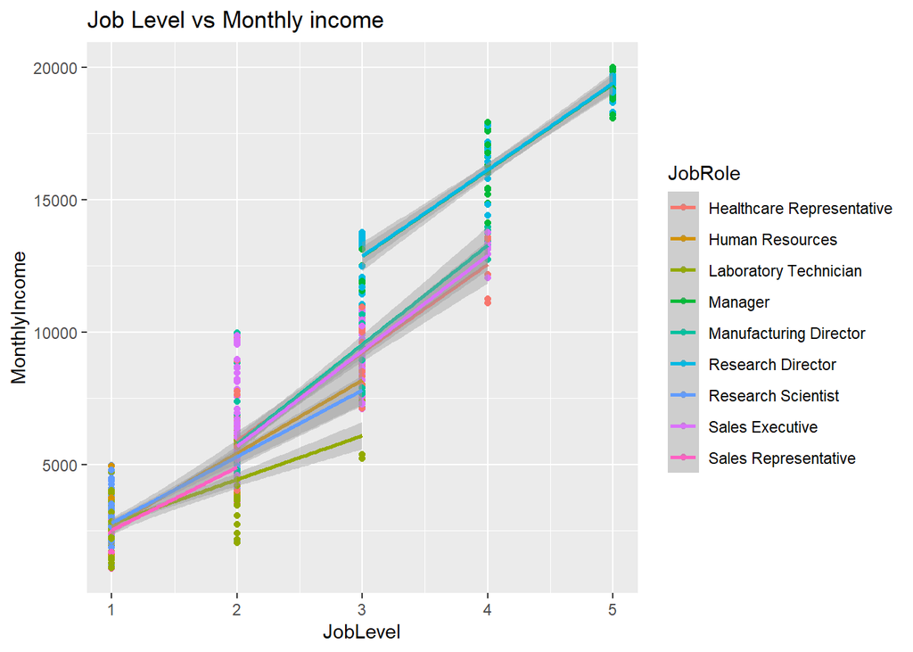

```r
#Job level linearly correlated with Monthly Income
plot = ggplot(data = data, aes(x = JobLevel, y=MonthlyIncome, col = JobRole)) +
  geom_point() + ggtitle("Job Level vs Monthly income") +geom_smooth(method  = "lm")
plot
```

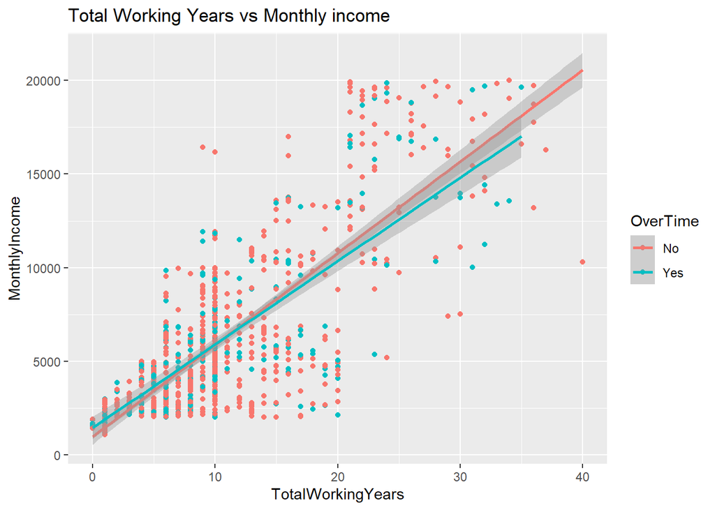

```r
#Total Working Years linearly correlated with Monthly Income
plot = ggplot(data = data, aes(x = TotalWorkingYears, y=MonthlyIncome, col = OverTime)) +
  geom_point() + ggtitle("Total Working Years vs Monthly income") +geom_smooth(method  = "lm")
plot
```

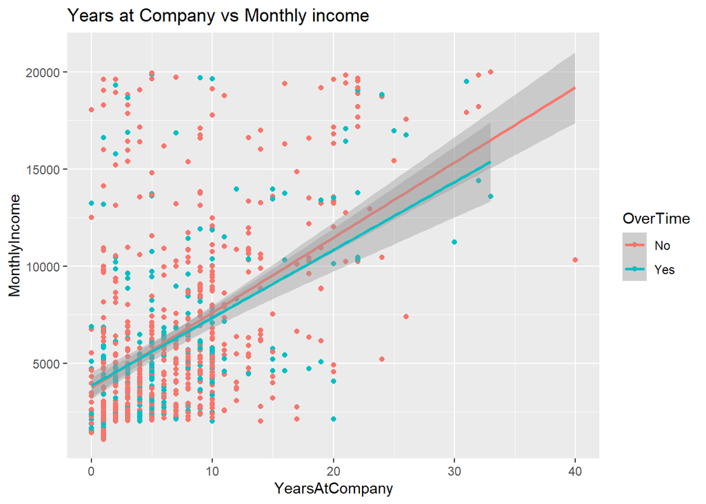

```r
#Years at Company correlated with MOnthly Income
plot = ggplot(data = data, aes(x = YearsAtCompany, y=MonthlyIncome, col = OverTime)) +
  geom_point() + ggtitle("Years at Company vs Monthly income") +geom_smooth(method  = "lm")
plot
```

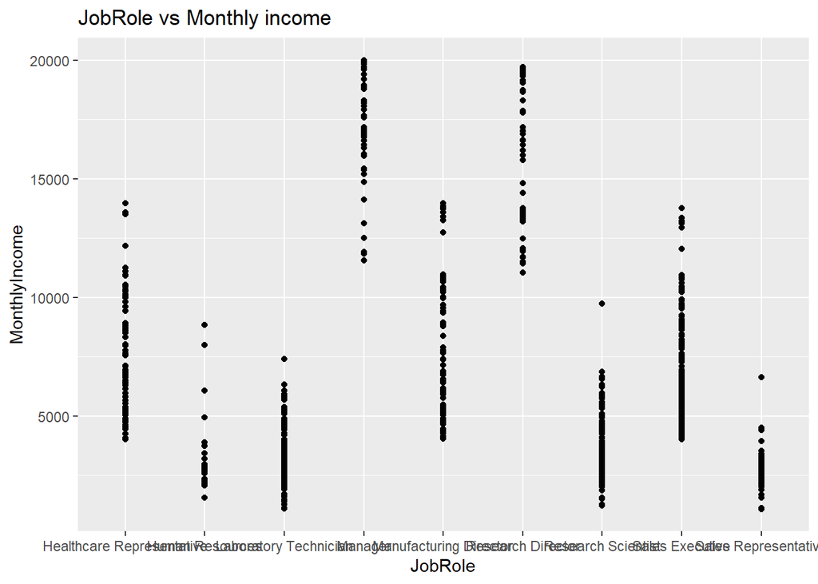

```r
plot = ggplot(data = data, aes(x = JobRole, y=MonthlyIncome)) +
  geom_point() + ggtitle("JobRole vs Monthly income") +geom_smooth(method  = "lm")
plot
```

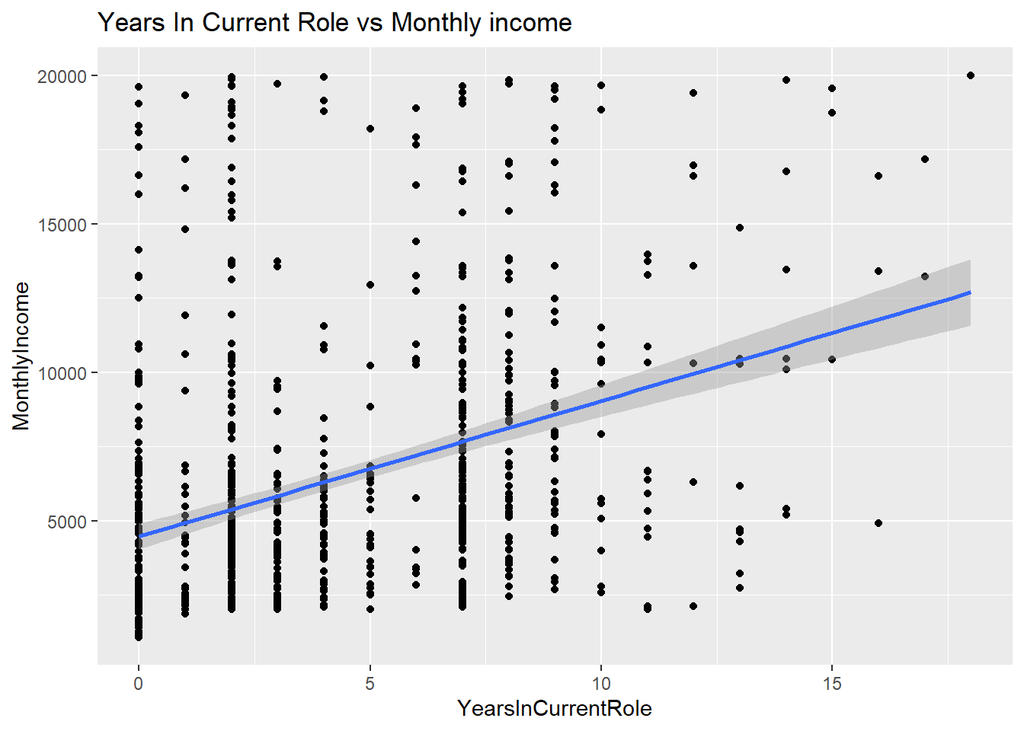

```r
plot = ggplot(data = data, aes(x = YearsInCurrentRole, y=MonthlyIncome)) +
  geom_point() + ggtitle("Years In Current Role vs Monthly income") +geom_smooth(method  = "lm")
plot
```

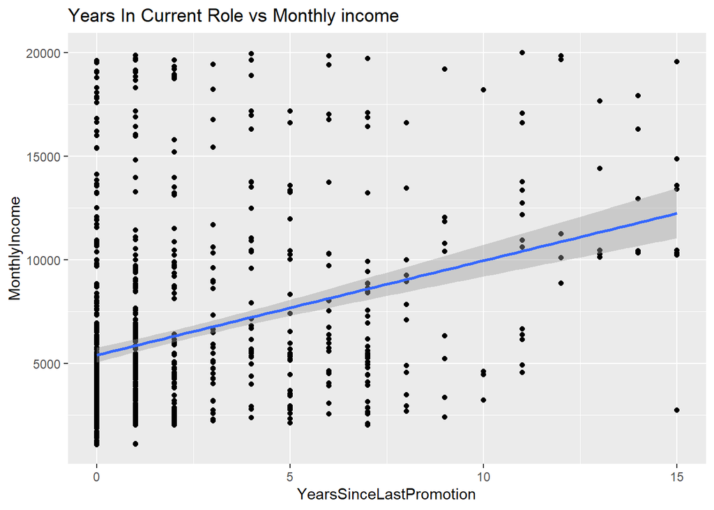

```r
plot = ggplot(data = data, aes(x = YearsSinceLastPromotion, y=MonthlyIncome)) +
  geom_point() + ggtitle("Years In Current Role vs Monthly income") +geom_smooth(method  = "lm")
plot
```

```r
# Worth looking at:
#   JobLevel
#   TotalWorkingYears
#   YearsAtCompany
#   JobRole
#   YearsInCurrentRole
#   YearsSinceLastPromotion


# Not worth looking at:
#   DailyRate
#   Education
#   DistanceFromHome
#   EducationField
#   Department
#   JobSatisfaction
```

## Fit models and calculate RMSE for each role separately

Using one model for all of the data was giving me an RMSE ~ 9000, since job role effects the slope and intercept of our model when looking at job level it seemed reasonable to create separate linear models based on job role, this gave me more reasonable RMSE values

```r
library(boot)

# split data by job role to create multiple models
options(warn = 0)
joblist = c("Healthcare Representative", "Human Resources", "Laboratory Technician", "Manager","Manufacturing Director","Research Director","Research Scientist","Sales Executive", "Sales Representative")

trainInd = sample(seq(1,dim(data)[1],1),round(.7*dim(data)[1]))
dataTrain = data[trainInd,]
dataTest = data[-trainInd,]
for (role in joblist){
  cat('role: ', role, '\n')
  trainrole = dataTrain[dataTrain$JobRole == role,]
  testrole = dataTest[dataTest$JobRole == role,]

  fit = glm(MonthlyIncome~JobLevel+TotalWorkingYears+YearsAtCompany+YearsInCurrentRole+YearsSinceLastPromotion, data = trainrole)

  cv2 = cv.glm(testrole,fit)
  MSE = cv2$delta
  RMSE = sqrt(cv2$delta)
  RMSE

  #summary(fit)
  pred = as.data.frame(predict(fit, data = dataTest[dataTest$JobRole == role,]))
  pred2 = as.data.frame(pred)
  residuals = dataTest[dataTest$JobRole == role,]$MonthlyIncome - pred
  RMSE = sqrt(sum(residuals^2)/length(dataTest[dataTest$JobRole == role,]$MonthlyIncome))
  RMSE
  cat('RMSE for ', role, ' is ',RMSE, '\n')

}
```

```
## role:  Healthcare Representative
## RMSE for  Healthcare Representative  is  3666.73
## role:  Human Resources
## RMSE for  Human Resources  is  4388.149
## role:  Laboratory Technician
## RMSE for  Laboratory Technician  is  2469.479
## role:  Manager
## RMSE for  Manager  is  4415.925
## role:  Manufacturing Director
## RMSE for  Manufacturing Director  is  4603.626
## role:  Research Director
## RMSE for  Research Director  is  6388.876
## role:  Research Scientist
## RMSE for  Research Scientist  is  2085.378
## role:  Sales Executive
## RMSE for  Sales Executive  is  5206.314
## role:  Sales Representative
## RMSE for  Sales Representative  is  1568.059
```

## Running our Attrition model on New data set

```r
data_No_Attrition = read.csv("D:\\MSDS\\DS 6306\\MSDS_6306_Doing-Data-Science\\Unit 14 and 15 Case Study 2\\CaseStudy2CompSet No Attrition.csv",header = TRUE)
datacols = cut_data[c(2,4:9,12:17, 19:24, 26, 28:36)]
dim(data_No_Attrition)
```

```
## [1] 300  35
```

```r
trained_cols = colnames(datacols)

data_No_attrition_cols = data_No_Attrition[trained_cols]

data_No_Attrition$Attrition = predict(model, data_No_Attrition[trained_cols])
table(data_No_Attrition$Attrition)
```

```
##
##  No Yes
## 210  90
```

```r
writeattrition <- data.frame(data_No_Attrition$ID, data_No_Attrition$Attrition)

colnames(writeattrition) <- c("ID","Attrition")
head(writeattrition)
```

```
##     ID Attrition
## 1 1171        No
## 2 1172       Yes
## 3 1173       Yes
## 4 1174        No
## 5 1175        No
## 6 1176        No
```

```r
write.csv(writeattrition,"D:\\Documents\\DDS_Project2\\Case2PredictionsChandwani Attrition.csv")
```

## Running our Monthly Income model on New data set

```r
data_No_Monthly = read.csv("D:\\MSDS\\DS 6306\\MSDS_6306_Doing-Data-Science\\Unit 14 and 15 Case Study 2\\CaseStudy2CompSet No Salary.csv",header = TRUE)
dim(data_No_Monthly)
```

```
## [1] 300  35
```

```r
dffinal = data.frame(matrix(ncol=2,nrow=0))
colnames(dffinal) <- c("ID","MonthlyIncome")

for (role in joblist){
  cat('role: ', role, '\n')
  dataforrole = data_No_Monthly[data_No_Monthly$JobRole == role,]


  fit = glm(MonthlyIncome~JobLevel+TotalWorkingYears+YearsAtCompany+YearsInCurrentRole+YearsSinceLastPromotion, data = data[data$JobRole == role,])


  dataforrole$MonthlyIncome = (predict(fit, dataforrole))

  writeMonthly <- data.frame(dataforrole$ID, dataforrole$MonthlyIncome)
  colnames(writeMonthly) <- c("ID","MonthlyIncome")
  dffinal <- rbind(dffinal,writeMonthly)
}
```

```
## role:  Healthcare Representative
## role:  Human Resources
## role:  Laboratory Technician
## role:  Manager
## role:  Manufacturing Director
## role:  Research Director
## role:  Research Scientist
## role:  Sales Executive
## role:  Sales Representative
```

```r
dfx =dffinal[order(dffinal$ID),]
head(dfx)
```

```
##      ID MonthlyIncome
## 213 871      5774.258
## 154 872      2705.111
## 214 873     12735.823
## 44  874      3071.601
## 45  875      3467.073
## 282 876      4792.430
```

```r
write.csv(dfx,"D:\\Documents\\DDS_Project2\\Case2PredictionsChandwani Salary.csv")
```